# ggplot2 & dplyr

## Quick scatterplot

```r
rm(list = ls())

library(datasets)
library(ggplot2)

head(iris,3)
```

```
##   Sepal.Length Sepal.Width Petal.Length Petal.Width Species
## 1          5.1         3.5          1.4         0.2  setosa
## 2          4.9         3.0          1.4         0.2  setosa
## 3          4.7         3.2          1.3         0.2  setosa
```

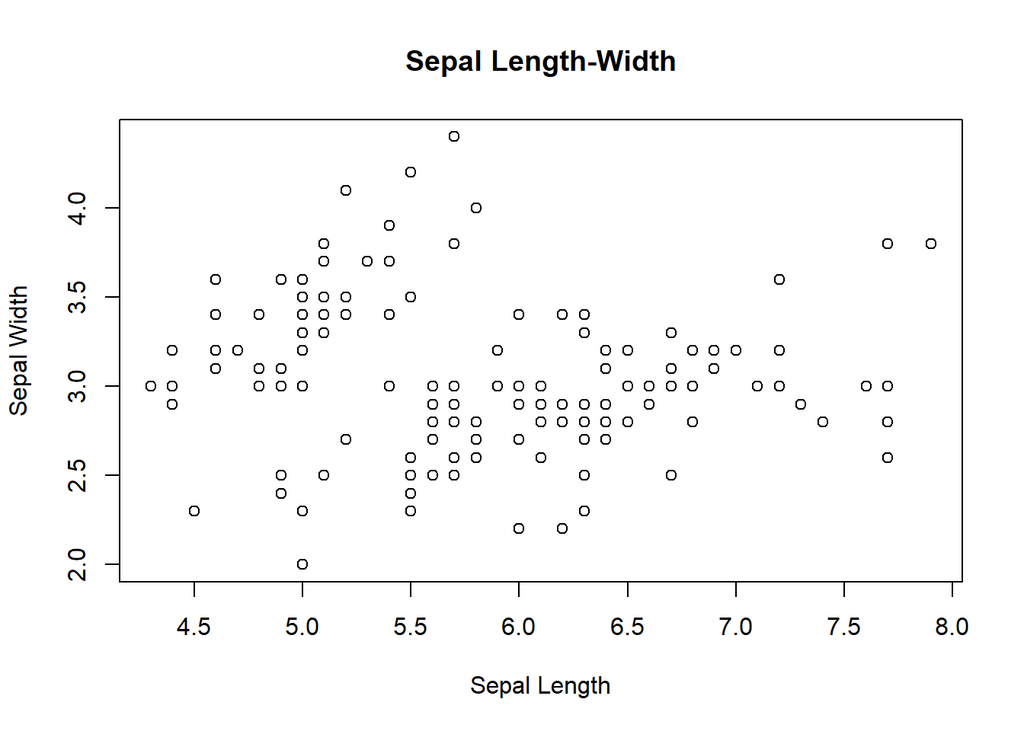

```r
plot(x=iris$Sepal.Length, y=iris$Sepal.Width,
     main="Sepal Length-Width", xlab="Sepal Length", ylab="Sepal Width")
```

## Change color and pch:

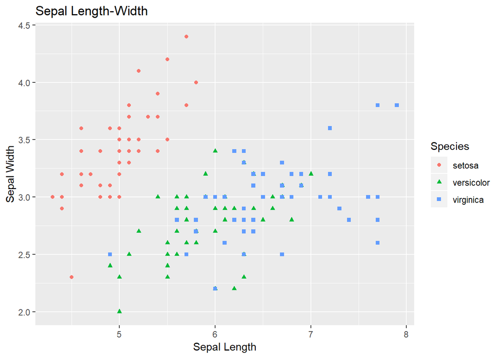

```r
scatter <- ggplot(data=iris, aes(x = Sepal.Length, y = Sepal.Width))
scatter + geom_point(aes(color=Species, shape=Species)) +
  ggtitle("Sepal Length-Width") + xlab("Sepal Length") +  ylab("Sepal Width")
```

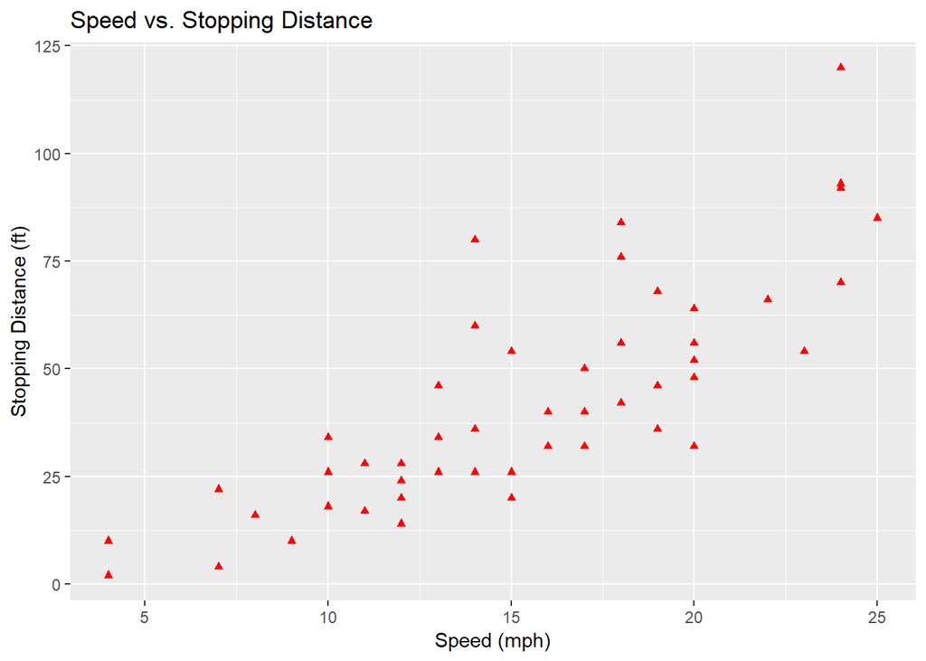

```r
ggplot(data=cars , aes(x=speed, y=dist)) +
  geom_point(col="red",pch = 17) +   # pch 17 ii the plotting 'character', i.e., symbol to use
  ggtitle("Speed vs. Stopping Distance") + xlab("Speed (mph)") + ylab("Stopping Distance (ft)")
```

## Boxplot

This is to compactly display the distribution of a continuous variable with five summary statistics: the median, two hinges and two whiskers, and all “outlying” points individually.

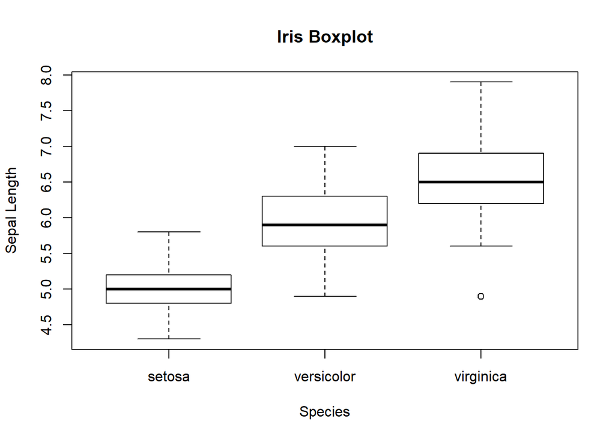

```r
boxplot(Sepal.Length~Species, data=iris, main="Iris Boxplot", xlab="Species", ylab="Sepal Length" )
```

## Create variables based on given conditions

```r
data(faithful)
head(faithful,3)
```

```
##   eruptions waiting
## 1     3.600      79
## 2     1.800      54
## 3     3.333      74
```

```r
# Create and set length values based on an eruption of 3.2 minute, for instance
faithful$length <- ifelse(faithful$eruptions<3.2, "short", "long")

# Set length as categorical data
faithful$length <-  as.factor(faithful$length)
class(faithful$length)
```

```
## [1] "factor"
```

```r
head(faithful,3)
```

```
##   eruptions waiting length
## 1     3.600      79   long
## 2     1.800      54  short
## 3     3.333      74   long
```

## Density Plot

A Density Plot visualises the distribution of data over a continuous interval or time period. This chart is a variation of a Histogram that uses kernel smoothing to plot values, allowing for smoother distributions by smoothing out the noise.

Use geom_vline to add a line for the mean.

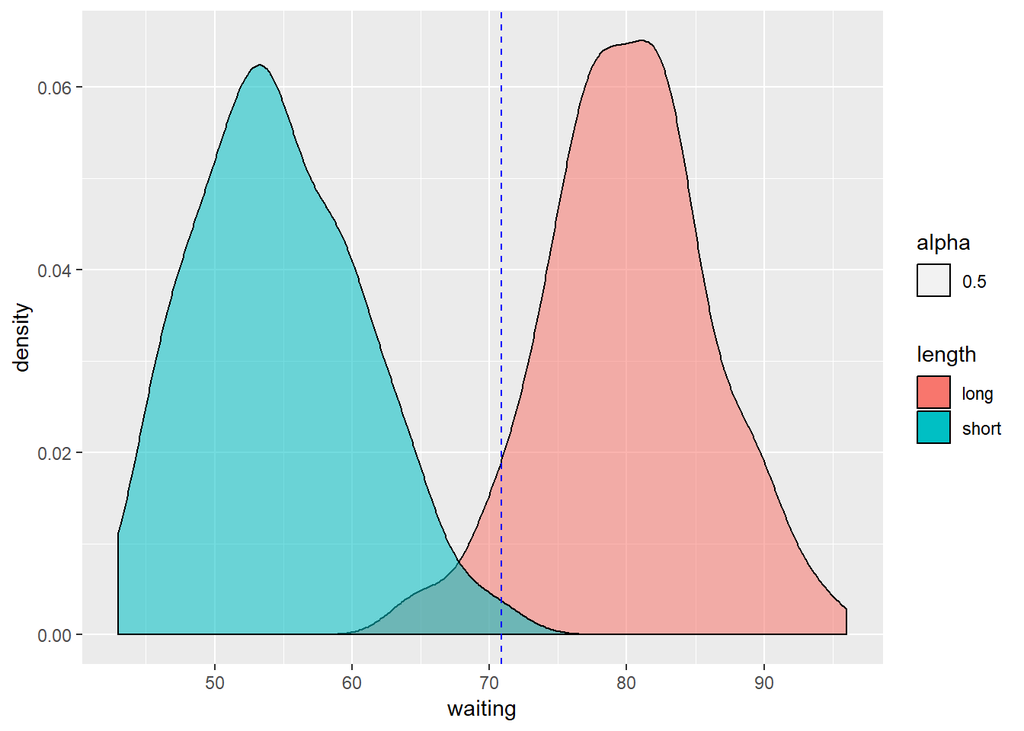

```r
ggplot(faithful, aes(x=waiting)) +
  geom_density(aes(fill=length, alpha=0.5)) +
  geom_vline(aes(xintercept=mean(waiting)),
            color="blue", linetype="dashed", size=0.5)
```

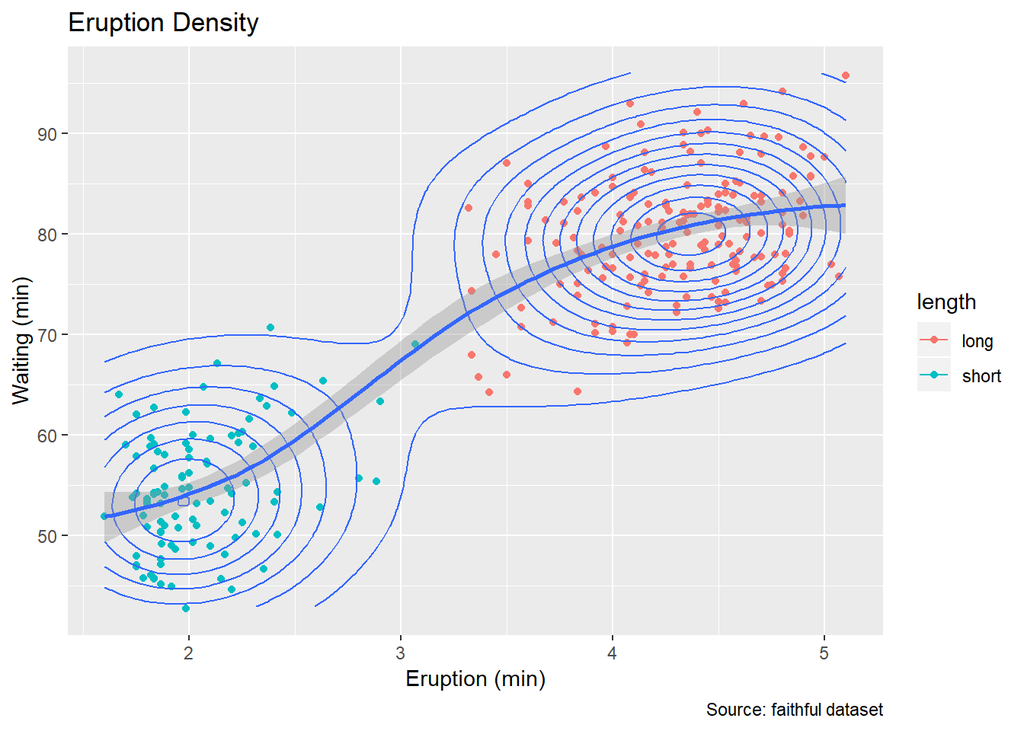

```r
ggplot(faithful, aes(x=eruptions, y=waiting)) +
  labs(
    title="Eruption Density",
    x="Eruption (min)",
    y="Waiting (min)",
    caption="Source: faithful dataset") +
  geom_jitter(aes(color = length)) + geom_density2d() +
  geom_smooth()
```

## Histogram

A histogram represents a frequency distribution by means of rectangles whose widths represent class intervals and whose areas are proportional to the corresponding frequencies: the height of each is the average frequency density for the interval.

In a histogram, data is grouped into “bins”. To calculate the bin width, find the range (maximum - minimum) and divide that by how many bins you’d like to have. A rough guideline for the number of bins is: take the square root of the number of data values you have.

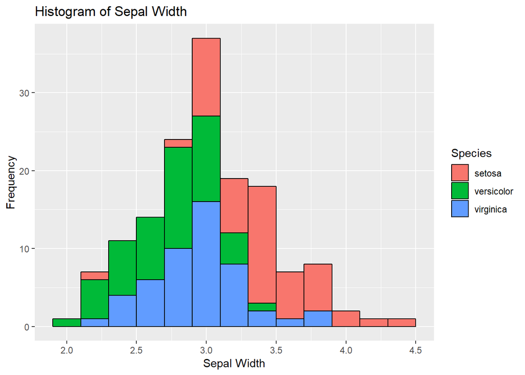

```r
histogram <- ggplot(data=iris, aes(x=Sepal.Width))
histogram + geom_histogram(binwidth=0.2, color="black", aes(fill=Species)) +
  ggtitle("Histogram of Sepal Width") +  xlab("Sepal Width") +  ylab("Frequency")
```

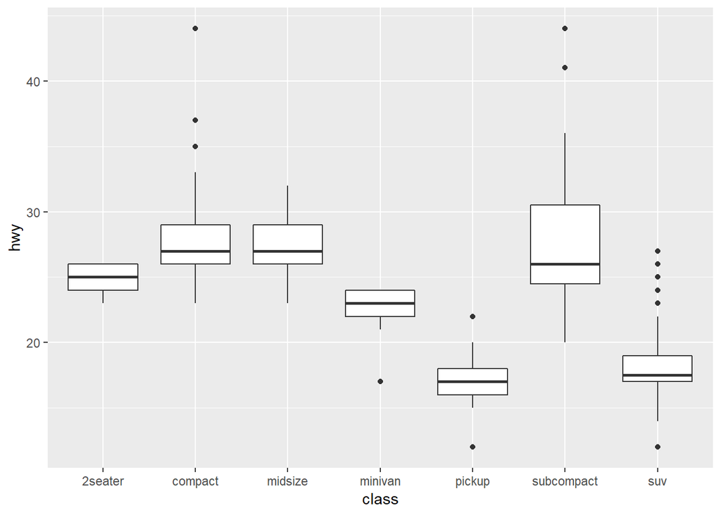

```r
p <- ggplot(mpg, aes(class, hwy))
p + geom_boxplot()
```

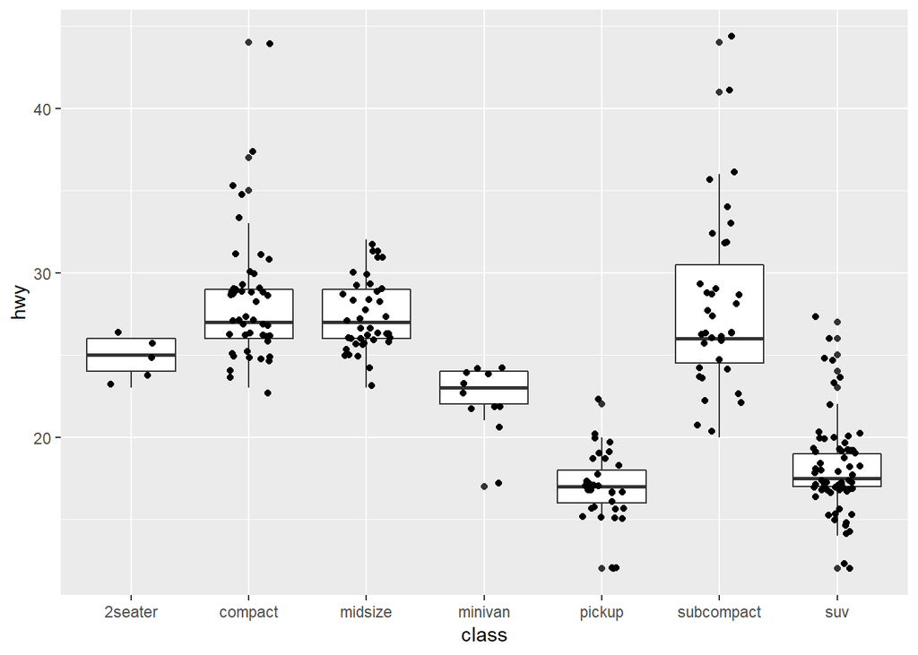

```r
p + geom_boxplot() + geom_jitter(width = 0.2)
```

## Knicks’ wining ratio

Calculate the winning ratio of New York Knicks in different seasons. Visualize how the winning ratio changes every year. (A bar plot is the most appropriate here.)

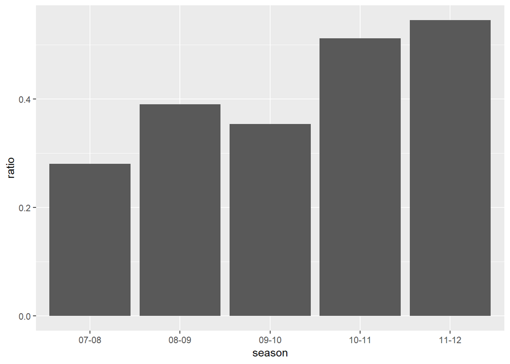

```r
library(dplyr)

load(url('https://s3.amazonaws.com/graderdata/Knicks.rda'))
knicks <- tbl_df(data)

knicks1 <- group_by(knicks, season) %>%
  summarise(ratio=sum(win=="W")/n())

ggplot(knicks1, aes(x=season, y=ratio)) + geom_bar(stat="identity")
```

```r
# Use stat = "identity" when y data is a column in a dataset.
# Default is to count data when setting stat = "bin".
```

Calculate the winning ratio for both home and away games. (The row labelled with visiting = 1 is an away game.) Create a bar plot to show home and away winning ratios for each season.

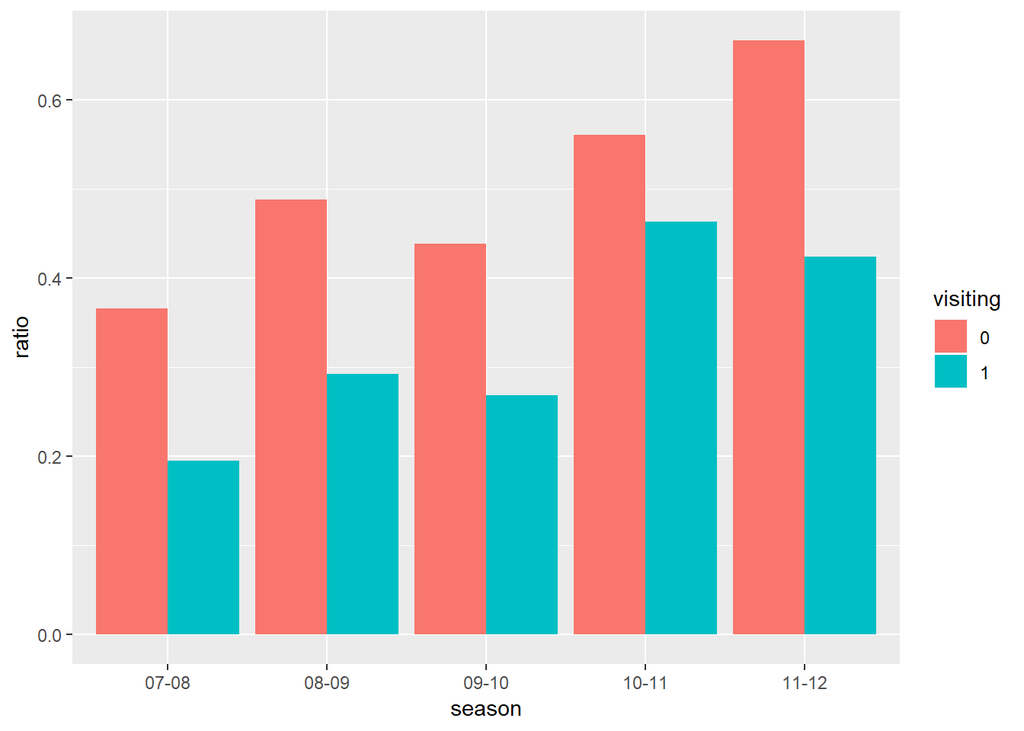

```r
knicks2 <- group_by(knicks, season, visiting) %>%
  summarise(ratio=sum(win=="W")/n())

ggplot(knicks2, aes(x=season,y=ratio)) +
  geom_bar(aes(fill=visiting), stat='identity', position='dodge')
```

Plot five histograms to display the distribution of points in each season.

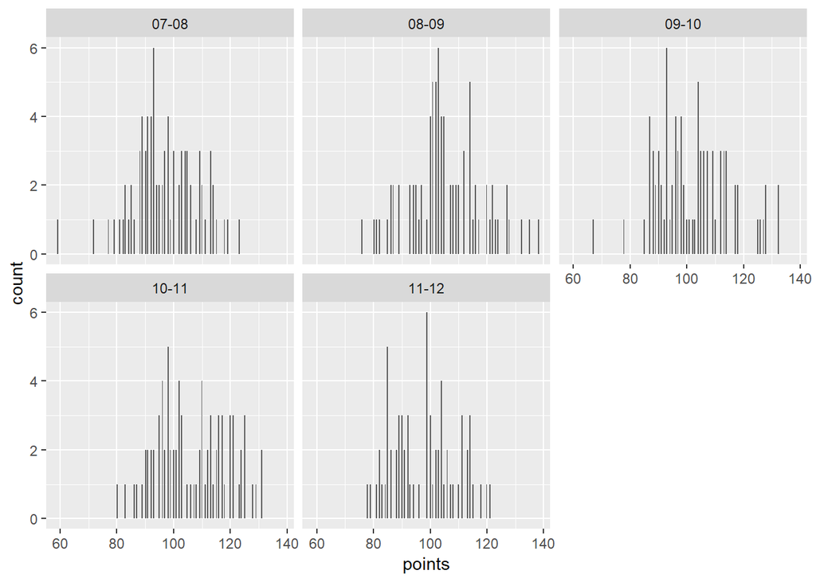

```r
ggplot(knicks,aes(x=points)) +
  geom_histogram(bins=200)+
  facet_wrap(~season)
```

Facet-warp wraps a 1d sequence of panels into 2d. (**Challenge**) Calculate the average winning ratio and the average point-difference (i.e., `points-opp`) by each opponent. Create a scatter-plot to show winning ratio versus average point-difference. What pattern do you see in the graph?

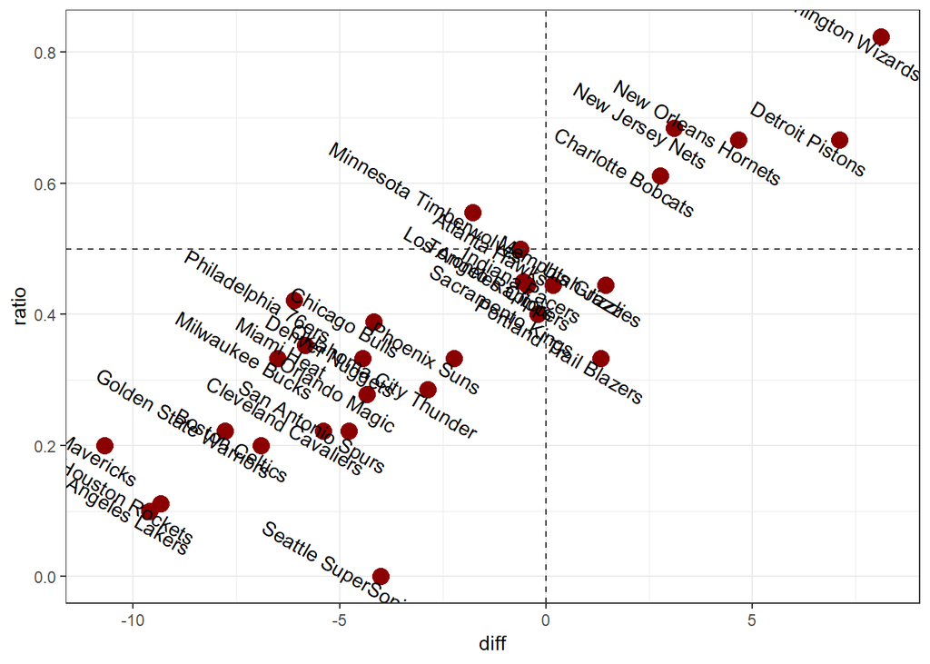

```r
knicks3 <- group_by(knicks, opponent) %>%
  summarise(ratio=sum(win=="W")/n(), diff=mean(points-opp))

ggplot(knicks3,aes(x=diff, y=ratio)) +
  geom_point(color='red4',size=4)+
  geom_hline(yintercept=0.5,colour='grey20',size=0.5,linetype=2)+
  geom_vline(xintercept=0,colour='grey20',size=0.5,linetype=2)+
  geom_text(aes(x=diff,y=ratio,label=opponent),
            hjust=0.7, vjust=1.4,angle = -30)+
  theme_bw()
```